BIO144 · FS 2027 · Unit 11, part 2

# Expand your mind: what next?

Data analysis beyond BIO144

Prof. Owen Petchey · University of Zurich

[figure not shown]

Look how far you've come

## What you can already analyse

Units 3–7

### Linear models

Data that meet their assumptions: regression, ANOVA, several explanatory variables, interactions.

Units 8–9

### GLMs

Count data and binary data.

Unit 11

### Mixed models

Grouped or repeated-measures data.

Unit 10

### Ordination

Many variables at once.

That's a lot. And there is much more to learn.

Think · Pair · Share

## What kind of data, or question, might you meet that BIO144 can't handle?

Klicker

Beyond BIO144

## Twelve situations, twelve families of methods

Tap one to jump to it

Not an exhaustive list. For each: what's the situation, what's the method, and where to start in R.

SituationI have a series of values through time

### Time series analysis

Observations close in time are usually similar: they are **not independent**, which breaks an assumption of most standard methods. Time series methods (e.g. ARIMA, seasonal decomposition, forecasting) handle this.

In R: `acf()` `forecast` `rEDM`

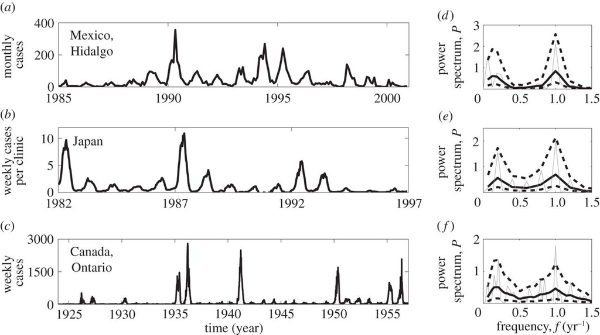

Disease cases through time. Rozhnova, G., Metcalf, C.J.E. & Grenfell, B.T. (2013) Characterizing the dynamics of rubella relative to measles: the role of stochasticity. *J. R. Soc. Interface*, 10.

SituationMy data points are distributed in space, and I have their locations (e.g. latitude and longitude)

### Spatial analysis

Nearby points tend to be similar (spatial autocorrelation), so again observations are **not independent**. Methods include spatial regression, kriging and geostatistics.

In R: the `Spatial` CRAN Task View

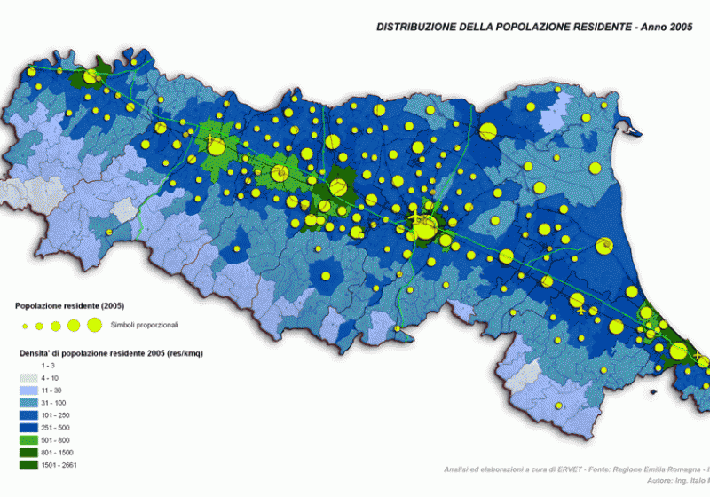

Points with locations: resident population across a region.

SituationThe relationship I would like to fit between two continuous variables is curvy!

### Nonlinear regression

Estimate the parameters of a specific non-linear function, such as logistic growth, f(x) = L / (1 + e<sup>−k(x−x₀)</sup>), and assess how well it fits.

In R: `nls()` (base R)

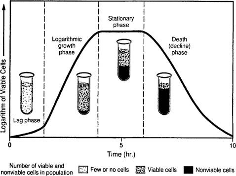

Phases of growth of a bacterial population.

SituationThe relationship between two continuous variables may have a discontinuity!

### Segmented, piecewise or breakpoint regression

The relationship changes at some point, e.g. before and after an intervention, or once a threshold is passed. Estimate where the break is, and the relationship on each side.

In R: `segmented`

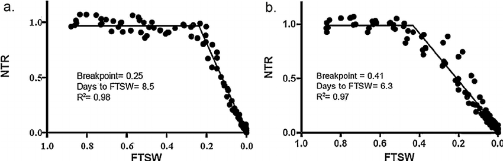

Normalised transpiration ratio vs fraction of transpirable soil water. Fuentealba, M.P. et al. (2016) Transpiration responses of warm-season turfgrass in relation to progressive soil drying. *Scientia Horticulturae*, 198, 249–253.

SituationI don't know, and don't care, what function to fit between my two continuous variables, but I do want one!

### Generalised additive models (GAMs)

Smooth functions capture non-linear effects, while the model stays interpretable. They extend the GLMs you know. Rather elegant!

In R: `mgcv`

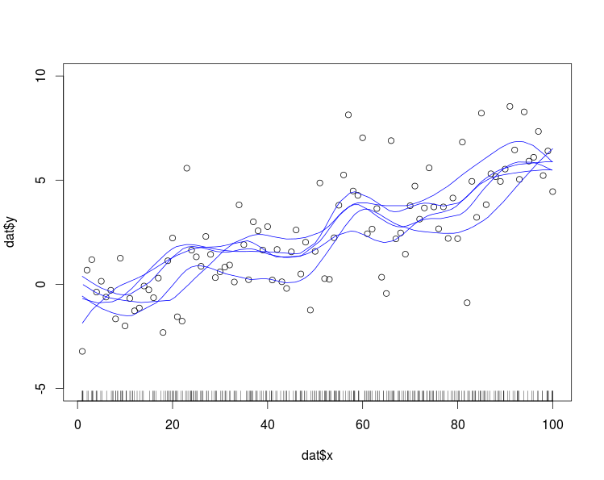

A smooth fitted through noisy data, with its uncertainty.

SituationI have a network, a system, of variables

### Path analysis and structural equation modelling (SEM)

Variables can be explanatory *and* response at the same time. Model direct and indirect effects, even latent variables: build and test causal models.

In R: `sem` `lavaan`

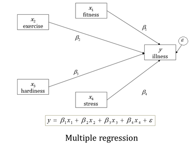

Multiple regression: every arrow goes to one response.

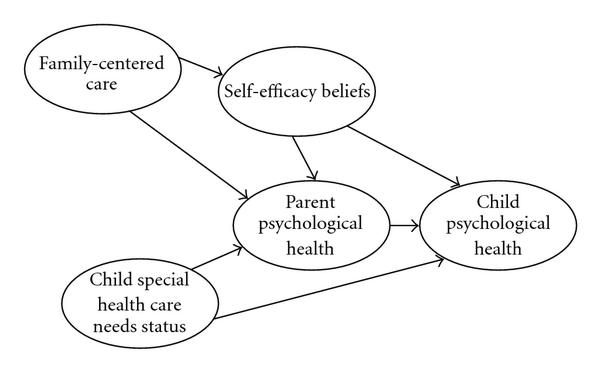

A path model: some variables are both causes and effects.

SituationI just want to predict…

### Machine learning

Decision trees, random forests, support vector machines, neural networks… They make predictions or classify, can handle large datasets and complex relationships, but may sacrifice interpretability.

```
install.packages(c(
  "ranger",   # random forests
  "xgboost",  # gradient boosting
  "glmnet",   # lasso/ridge/elastic net
  "kernlab",  # support vector machines
  "kknn",     # k-nearest neighbours
  "earth",    # adaptive regression splines
  "nnet"      # simple neural networks
))
```

SituationI'm reviewing and analysing the results of many studies

### Meta-analysis

Combine the effect sizes from different studies to draw broader conclusions, and assess how much they differ (heterogeneity). Another reason to report effect sizes (Principle 3).

In R: `metafor` (and others)

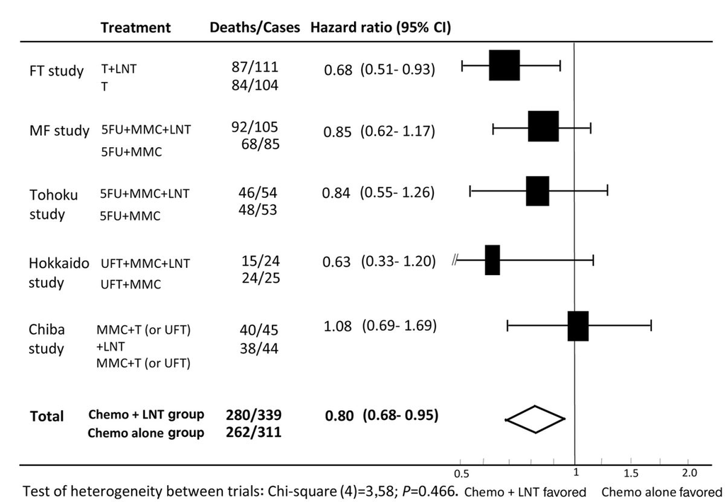

A forest plot: one estimate per study, and the combined estimate (diamond). Oba, K. et al. (2009) Individual patient based meta-analysis of lentinan for unresectable/recurrent gastric cancer. *Anticancer Research*, 29, 2739–45.

SituationMy response variable is the amount of time until something happened

### Survival analysis

Time-to-event data: time until death, failure, germination, flowering… Some individuals haven't had the event by the end of the study (**censoring**). Kaplan–Meier curves, Cox proportional hazards models.

In R: `survival` (and others)

**type**: tumour DNA profile (1 aneuploid, 2 diploid) · **time**: weeks to death or end of study · **delta**: 0 alive, 1 dead

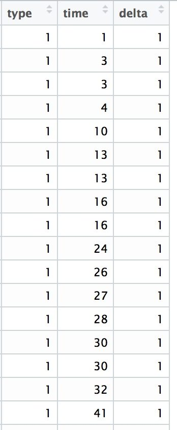

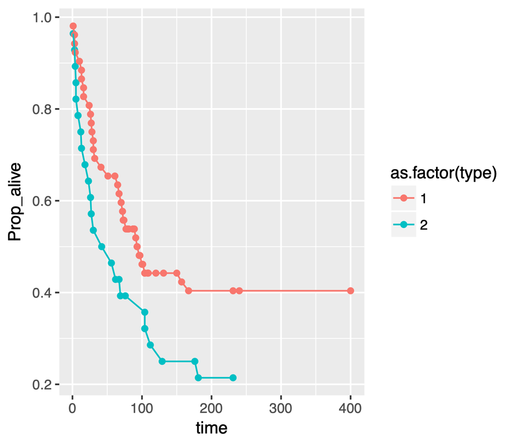

Proportion alive through time, for the two tumour types.

SituationI can't fix my residuals

### Nonparametric methods

Rank-based tests, bootstrapping and permutation tests make fewer assumptions about the distribution of the data.

In R: base R, e.g. `kruskal.test()` (and other packages)

**Kruskal–Wallis** is somewhat equivalent to a **one-way ANOVA**, on the ranks of the data.

But first: can you make a model that fits, e.g. a transformation, or a GLM with a suitable distribution (Principle 2)?

SituationI want to make sure my planned experiment has adequate statistical power

### Power analysis

Power is the probability of detecting an effect if it is really there. It depends on the **effect size**, the **variation**, the **number of observations** and the **significance level**. Use it to work out the sample size you need, before you collect data.

In R: `pwr`

Try it: comparing two groups

Effect size (d) People per group

Power

Per group for 80% power

d = difference in means divided by the standard deviation. Normal approximation to a two-sample t-test.

SituationI have some prior information

### Bayesian statistics

Combine prior knowledge with the data, using Bayes' theorem: P(H | E) = P(E | H) P(H) / P(E). The result, the posterior, describes what we believe after seeing the data, with its uncertainty.

In R: `rstan` `R-INLA` `rjags` · Book: *Statistical Rethinking* (McElreath)

Try it: what proportion of seeds germinate?

Prior guess Prior strength Seeds sown Germinated

## Some methods are not mutually exclusive

### Combined

Repeated measures through time: mixed models *and* time series. Counts across space: GLMs *and* spatial methods.

### Extended

GAMs extend GLMs. Mixed models can be GLMs (GLMMs).

### Bayesian versions

Bayesian methods can be used for most of them.

And there are multiple books about each.

Your turn

## Two pieces of advice

1 · Plan ahead

### Plan the analysis when you design the study

Including the sample size you need (power analysis). Then you collect the right data to answer your question. When something changes, explore the options and talk to experts.

2 · Question first

### Be driven by your questions, not by techniques

We don't analyse data for its own sake, but to answer questions about the world. Let your questions guide what you learn next.

Principle 1 from Week 1: a focused question first, then plan sampling and analysis to answer it.

## Where to start learning more

### CRAN Task Views

Curated lists of R packages, by topic:

`TimeSeries` `Spatial` `MachineLearning` `MetaAnalysis` `Survival` `Bayesian` `Psychometrics` (SEM) `ExperimentalDesign` `Environmetrics`

cran.r-project.org/web/views

### Statistical Rethinking

Richard McElreath's book on multilevel Bayesian modelling, with free lecture videos.

### The course book

Chapter 11.2 lists all twelve, with what each is for.

### People

Statisticians, and colleagues who use the methods. Ask early.

SituationI want to work as a data scientist or analyst, and make lots of money

A recruiter in quantitative finance and technology told me: after a science Masters or PhD, the most common first job was **quantitative researcher**, **quantitative analyst** or **data scientist**. The skills asked for:

- machine learning (over the past few years, a must)
- working with large datasets: manipulation and visualisation
- programming, e.g. Python; research languages such as R
- time series analysis and forecasting

We do all of these in my ecology group :)

### Machine learning, time series analysis, forecasting

Listening: *Data Analytics in the Liberal Arts*; *How to Build Analytics Technical Skills* (How to Get an Analytics Job podcast).

## R and RStudio evolve

[figure not shown]

Then: R on its own.

[figure not shown]

Now: RStudio, the tidyverse, the native pipe |>, Quarto…

So do the books: *Getting Started with R* (Beckerman & Petchey 2012; 2nd ed. with Childs, 2017), *Insights from Data with R* (Petchey et al. 2021). Keep learning, and keep updating.

## Statistical methods and thinking evolve too

Ordinary multiple regression was once considered cutting edge: something only experts would fiddle with.

Paraphrasing Richard McElreath, *Statistical Rethinking*.

Today's specialist method (e.g. multilevel Bayesian modelling) may be tomorrow's standard tool.

Finally

## Can all problems be solved with data and analyses?

Necessary, but **not sufficient**. Think of the UN Sustainable Development Goals: poverty, hunger, health, climate, life on land and in water.

And “we need more data before we act” is often no longer a good argument.

## Until next week…

Before Monday

### Tell us

Post on the OLAT forum what you'd like to go over in the review.

Mon 31 May

### Unit 12: Review

Planning and implementing statistical analyses.

Fri 4 June

### Last practical

The only practical that week: the Thursday group comes on Friday.

Fri 18 June

### Final exam

10:00–12:00. Mandatory Probeprüfung before then.

BIO144 · Week 11 · What next?